# Notebook

[Sebastian Raschka](http://sebastianraschka.com)  
last updated: 06/02/2014

- [Open in IPython nbviewer](http://nbviewer.ipython.org/github/rasbt/One-Python-benchmark-per-day/blob/master/ipython_nbs/day6_string_is_number.ipynb?create=1)
- [Link to this IPython notebook on Github](https://github.com/rasbt/One-Python-benchmark-per-day/blob/master/ipython_nbs/day6_string_is_number.ipynb)
- [Link to the GitHub Repository One-Python-benchmark-per-day](https://github.com/rasbt/One-Python-benchmark-per-day)

I would be happy to hear your comments and suggestions.  
Please feel free to drop me a note via [twitter](https://twitter.com/rasbt), , or [google+](https://plus.google.com/118404394130788869227).

# Day 6 - One Python Benchmark per Day

## Determining if a string is a number

**-> skip to the results**

For this benchmark, we will be testing different approaches to determine is a string is a number.

**Note that methods like `.isdigit()` and `.isnumeric()` are only evaluating if a string in an integer**,  
e.g., both `'1.2'.isdigit()` and `'1.2'.isnumeric()` return `False`.

## Functions

```python
def is_number_tryexcept(s):
    """ Returns True is string is a number. """
    try:
        float(s)
        return True
    except ValueError:
        return False
```

```python
from re import match as re_match

def is_number_regex(s):
    """ Returns True is string is a number. """
    if re_match("^\d+?\.\d+?$", s) is None:
        return s.isdigit()
    return True
```

```python
from re import compile as re_compile

comp = re_compile("^\d+?\.\d+?$")

def compiled_regex(s):
    """ Returns True is string is a number. """
    if comp.match(s) is None:
        return s.isdigit()
    return True
```

```python
def is_number_repl_isdigit(s):
    """ Returns True is string is a number. """
    return s.replace('.','',1).isdigit()
```

```python
import re

%timeit re_match("^\d+?\.\d+?$", '1.2345')
%timeit re.match("^\d+?\.\d+?$", '1.2345')
```

```
1000000 loops, best of 3: 1.3 µs per loop
1000000 loops, best of 3: 1.36 µs per loop
```

## Testing the functions for correct behavior

```python
a_float = '1.1234'
inv_float = '1.12.34'
no_number = 'abc123'
an_int = '12345'

funcs = [
          is_number_tryexcept,
          is_number_regex,
          compiled_regex,
          is_number_repl_isdigit
          ]

for f in funcs:
    assert (f(a_float) == True), 'Error in %s(%s)' %(f.__name__, a_float)
    assert (f(inv_float) == False), 'Error in %s(%s)' %(f.__name__, inv_float)
    assert (f(no_number) == False), 'Error in %s(%s)' %(f.__name__, no_number)
    assert (f(an_int) == True), 'Error in %s(%s)' %(f.__name__, an_int)
print('ok')
```

```
ok
```

## Special cases where those functions do not work

```python
a_float = '.1234'

print('Float notation ".1234" is not supported by:')
for f in funcs:
    if not f(a_float):
        print('\t -', f.__name__)
```

```
Float notation ".1234" is not supported by:
	 - is_number_regex
	 - compiled_regex
```

### Scientific notations

```python
scientific1 = '1.000000e+50'
scientific2 = '1e50'


print('Scientific notation "1.000000e+50" is not supported by:')
for f in funcs:
    if not f(scientific1):
        print('\t -', f.__name__)

print('Scientific notation "1e50" is not supported by:')
for f in funcs:
    if not f(scientific2):
        print('\t -', f.__name__)
```

```
Scientific notation "1.000000e+50" is not supported by:
	 - is_number_regex
	 - compiled_regex
	 - is_number_repl_isdigit
Scientific notation "1e50" is not supported by:
	 - is_number_regex
	 - compiled_regex
	 - is_number_repl_isdigit
```

## Timing the functions

```python
import timeit

test_cases = ['1.12345', '1.12.345', 'abc12345', '12345']
times_n = {f.__name__:[] for f in funcs}

for t in test_cases:
    for f in funcs:
        f = f.__name__
        times_n[f].append(min(timeit.Timer('%s(t)' %f,
                      'from __main__ import %s, t' %f)
                              .repeat(repeat=3, number=1000000)))
```

### Preparing the plots

```python
%matplotlib inline
```

```python
import platform
import multiprocessing

def print_sysinfo():

    print('\nPython version  :', platform.python_version())
    print('compiler        :', platform.python_compiler())

    print('\nsystem     :', platform.system())
    print('release    :', platform.release())
    print('machine    :', platform.machine())
    print('processor  :', platform.processor())
    print('CPU count  :', multiprocessing.cpu_count())
    print('interpreter:', platform.architecture()[0])
    print('\n\n')
```

```python
from numpy import arange
import matplotlib.pyplot as plt

def plot():
    labels = [('is_number_tryexcept','Try-except method'),
          ('is_number_regex', 'Regular expression'),
          ('compiled_regex', 'Compiled regular expression'),
          ('is_number_repl_isdigit', 'replace-isdigit method')
          ]

    x_labels = ['float: "1.12345"',
            'invalid float: "1.12.345"',
            'no number: "abc12345"',
            'integer: "12345"']

    plt.rcParams.update({'font.size': 12})

    ind = arange(len(test_cases))  # the x locations for the groups
    width = 0.2

    fig = plt.figure(figsize=(12,8))
    ax = fig.add_subplot(111)
    colors = [(0,'c'), (1,'b'), (2,'g'), (3,'r')]

    for l,c in zip(labels,colors):
        ax.bar(ind + c[0]*width,
            times_n[l[0]],
            width,
            alpha=0.5,
            color=c[1],
            label=l[1])
    plt.grid()
    ax.set_ylabel('time in microseconds')
    ax.set_title('Methods for determening if a string is a number')
    ax.set_xticks(ind + width)
    ax.set_xticklabels(x_labels)
    plt.legend(loc='upper right', fontsize=13)
    plt.xlim([-0.2, 3.8])
    plt.ylim([-0, 2])
    plt.show()
```

# Results

```
Python version  : 3.4.0
compiler        : GCC 4.2.1 (Apple Inc. build 5577)

system     : Darwin
release    : 13.2.0
machine    : x86_64
processor  : i386
CPU count  : 4
interpreter: 64bit
```

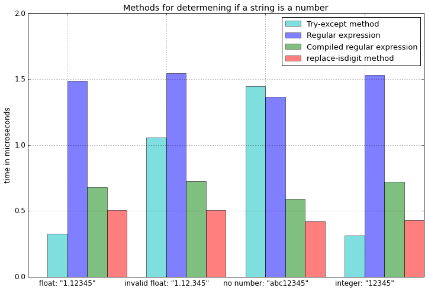

```python
print_sysinfo()
plot()
```

## Conclusion

The `try-except` approach appears to be slower than the replace-isdigit method for cases where the string is not a number - executing the `except-block` seems to be very costly. However, we have to consider that it also works for special cases like:  
- '1.000000e+50'  
- '1e50'  
- '.12345'

So it really depends on the data set which method to choose - the more thorough "try-except" or the faster "replace-isdigit"